# Grossepieper_Nils_Assignment05_R

Nils Grossepieper

2023-01-25

1. Register on github.com in case you have not done this already.

Done.

2. Initialize a new public repository for this assignment on GitHub.

Connected to the public repository Grossepieper_Nils_Assignment05

3. For the following exercises of this assignment, follow the standard Git workflow (i.e., pull the latest version of the project to your local computer, then stage, commit, and push all the modifications that you make throughout the project). Every logical programming step should be well documented on GitHub with a meaningful commit message, so that other people (e.g., your course instructor) can follow and understand the development history. You can do this either using Shell commands or a Git GUI of your choice.

Future changes in this script will be commented on git.

4. In the HTML file that you submit, include the hyperlink to the project repository (e.g., https://github.com/yourUserName/yourProjectName)

Here is the hyperlink to my git repository: https://github.com/NilsGrossepieper/Grossepieper_Nils_Assignment05.git

5. Visit the documentation website for the API provided by ticketmaster.com (see here). Familiarize yourself with the features and functionalities of the Ticketmaster Discovery API. Have a particular look at rate limits.

6. Whithin the scope of this assignment, you do not have to request your own API key. Instead retrieve a valid key from the API Explorer. This API key enables you to perform the GET requests needed throughout this assignment. Even though this API key is not secret per se (it is publicly visible on the API Explorer website), please comply to the common secrecy practices discussed in the lecture and the tutorial: Treat the API key as a secret token. Your API key should neither appear in the code that you are submitting nor in your public GitHub repository.

```r
# Read the script with the API key:
source("C:/Users/gross/OneDrive/Dokumente/data/ticket_master_api_key_script.R")
```

7. Perform a first GET request, that searches for event venues in Germany (countryCode = “DE”). Extract the content from the response object and inspect the resulting list. Describe what you can see.

```r
# Import all necessary libraries:
library(httr)
library(tidyverse)
library(magrittr)
```

```r
library(maps)
# Search for all venues in Germany (page1) (where countryCode = 'DE')
res_venue_ger <- GET(url = "https://app.ticketmaster.com/discovery/v2/venues/",
                     query = list(apikey = ticket_master_key,
                                  "countryCode" = "DE", "locale" = "*"))

# Print out the query:
con_venue_ger <- content(res_venue_ger)
con_venue_ger
```

```
## $`_embedded`
## $`_embedded`$venues
## $`_embedded`$venues[[1]]
## $`_embedded`$venues[[1]]$name
## [1] "Grosse Freiheit 36"
##
## $`_embedded`$venues[[1]]$type
## [1] "venue"
##
## $`_embedded`$venues[[1]]$id
## [1] "KovZpZAn6vEA"
##
## $`_embedded`$venues[[1]]$test
## [1] FALSE
##
## $`_embedded`$venues[[1]]$url
## [1] "http://www.ticketmaster.de/venue/287636"
##
## $`_embedded`$venues[[1]]$locale
## [1] "en-de"
##
## $`_embedded`$venues[[1]]$images
## $`_embedded`$venues[[1]]$images[[1]]
## $`_embedded`$venues[[1]]$images[[1]]$ratio
## [1] "16_9"
##
## $`_embedded`$venues[[1]]$images[[1]]$url
## [1] "https://s1.ticketm.net/dbimages/962v."
##
## $`_embedded`$venues[[1]]$images[[1]]$width
## [1] 205
##
## $`_embedded`$venues[[1]]$images[[1]]$height
## [1] 115
##
## $`_embedded`$venues[[1]]$images[[1]]$fallback
## [1] FALSE
##
##
##
```

[output cut: 1577 more lines]

```
##
##
##
## $page
## $page$size
## [1] 20
##
## $page$totalElements
## [1] 12932
##
## $page$totalPages
## [1] 647
##
## $page$number
## [1] 0
```

```r
# You can see several lists that are sub-lists of other lists. For each venue you
# can find different attributes like the name, the address or the coordinates
# (longitude and latitude). These attributes are not located all on the same layer
# but longitude and latitude for example are located at different layers than name.
# At the end of the output you can see how many elements and pages are contained
# in the API request for 'DE'. In total we have 12932 elements on 647 pages with 20
# entries per page (the last) page does not have the full 20 entries.
```

8. Extract the name, the city, the postalCode and address, as well as the url and the longitude and latitude of the venues to a data frame.

```r
# name
# extract the name information:
name <- map_chr(con_venue_ger$`_embedded`$venues, "name")

# city
# create empty city vector:
city <- c()
# loop over all 20 venues:
for (i in 1:20) {
  # add the cities to the vector
  city <- append(city, con_venue_ger$`_embedded`$venues[[i]]$city$name)
}

# postalCode
# create postal code vector (map_dpl does not work), default to:
postalCode <- as.double(map_chr(con_venue_ger$`_embedded`$venues, "postalCode",
                                .default = "NA"))

# address
# create an empty address vector:
address <- c()
# append values via loop
# if there is no such value create NA:
for (i in 1:20) {
  address <- append(address,
                   ifelse(is.null(con_venue_ger$`_embedded`$venues[[i]]$address$line1),
                          NA, con_venue_ger$`_embedded`$venues[[i]]$address$line1))
}

# url
# extract the url information:
url <- map_chr(con_venue_ger$`_embedded`$venues, "url")

# longitude
# create empty vector longitude-vector:
longitude <- c()
# loop over all 20 venues
# if the value does not exist -> NA, else append by the specific value
for (i in 1:20) {
  # add values to longitude vector
  longitude <- append(longitude,
                      ifelse(is.null(con_venue_ger$`_embedded`$venues[[i]]$location$longitude),
                             NA, con_venue_ger$`_embedded`$venues[[i]]$location$longitude))
}
# change the data type to double
longitude <- as.double(longitude)

# latitude
# create empty vector latitude-vector
latitude <- c()
# loop over all 20 venues
# if the value does not exist -> NA, else append by the specific value
for (i in 1:20) {
  # add name to longitude vector
  latitude <- append(latitude,
                      ifelse(is.null(con_venue_ger$`_embedded`$venues[[i]]$location$latitude),
                             NA, con_venue_ger$`_embedded`$venues[[i]]$location$latitude))
}
# change the data type to double
latitude <- as.double(latitude)

# create the data frame:
venue_ger <- data.frame(name, city, postalCode, address, url, longitude, latitude)
venue_ger
```

```
##                          name              city postalCode
## 1          Grosse Freiheit 36           Hamburg      22767
## 2                   Gruenspan           Hamburg      22767
## 3           Huxleys Neue Welt            Berlin      10967
## 4             Zentrum am Park      Emmelshausen      56281
## 5    Stadthalle (Theatersaal)           Mülheim      45479
## 6               Schlossgarten          Bruchsal      76646
## 7                  Stadthalle        Hockenheim      68766
## 8                         FZW          Dortmund      44263
## 9                 Arena Trier             Trier      54292
## 10              Eissporthalle         Memmingen      87700
## 11      Stadthalle Gersthofen        Gersthofen      86368
## 12      Feierwerk (Kranhalle)            Munich      81373
## 13       Feierwerk (Hansa 39)            Munich      81373
## 14 Burghof - STIMMEN-Festival           Lörrach      79539
```

[output cut: 69 more lines]

```r
# Create a function that creates the data frame.
create_df <- function(countryCode){
  page <- GET(url = "https://app.ticketmaster.com/discovery/v2/venues/",
                     query = list(apikey = ticket_master_key,
                                  "countryCode" = countryCode, "locale" = "*"))
  # set the sleeping time according to the website
  Sys.sleep(0.2)
  con_page <- content(page)
  nr_pages <- con_page$page$totalPages
  nr_entries <- con_page$page$size
  # create an empty data frame
  df_all <- data.frame(name = character(),
                       city = character(),
                       postalCode = double(),
                       address = character(),
                       url = character(),
                       longitude = double(),
                       latitude = double())
  # create a loop which loops over all pages:
  for (p in 0:(nr_pages - 1)) {

    # often the api requests throws out an error when looping over multiple pages
    # that is why while loop is introduced
    control <- NULL
    while(is.null(control)) {

    page <- GET(url = "https://app.ticketmaster.com/discovery/v2/venues/",
                     query = list(apikey = ticket_master_key,
                                  "countryCode" = countryCode,
                                  "page" = p, "locale" = "*"))
    content = content(page)

    control <- content$`_embedded`$venues
  }

# the last page is usually not full
# to get the number of elements on the last page this if-statement is created:
if (p == (nr_pages - 1)) {
  nr_entries = con_page$page$totalElements %% nr_entries
}

## name
name <- map_chr(content$`_embedded`$venues, "name", .default = NA)

## city
# create empty city-vector
city <- c()
# loop over all 20 venues
for (i in 1:nr_entries) {
  # add name to city vector
  city <- append(city, ifelse(is.null(content$`_embedded`$venues[[i]]$city$name),NA,
                              content$`_embedded`$venues[[i]]$city$name))
}


## postal code
# create postal code vector (map_dbl does not work), default to prevent error if value is missing
postalCode <- as.double(map_chr(content$`_embedded`$venues, "postalCode", .default = NA))


## address
# create empty adress vector
address <- c()
# append values via loop
# if there is no such value create NA
for (i in 1:nr_entries) {
  address <- append(address, ifelse(is.null(content$`_embedded`$venues[[i]]$address$line1),
                                    NA, content$`_embedded`$venues[[i]]$address$line1))
}

## url
# create url vector
url <- map_chr(content$`_embedded`$venues, "url", .default = NA)

## longitude
# create empty longitude-vector
longitude <- c()
# loop over all 20 venues
# if the value does not exist ->NA, else append by the specific value
for (i in 1:nr_entries) {
  # add name to longitude vector
  longitude <- append(longitude, ifelse(is.null(content$`_embedded`$venues[[i]]$location$longitude),
                                    NA, content$`_embedded`$venues[[i]]$location$longitude))
}
# change datatype to double
longitude <- as.double(longitude)

## latitude
# create empty latitude-vector
latitude <- c()
# loop over all 20 venues
# if the value does not exist ->NA, else append by the specific value
for (i in 1:nr_entries) {
  # add name to longitude vector
  latitude <- append(latitude, ifelse(is.null(content$`_embedded`$venues[[i]]$location$latitude),
                                    NA, content$`_embedded`$venues[[i]]$location$latitude))
}
# change datatype to double
latitude <- as.double(latitude)

# create data frame
df_page <- data.frame(name, city, postalCode,address, url, longitude, latitude)

df_all <- rbind(df_all, df_page)

Sys.sleep(0.2)

  }
  # set the data frame as the output of the function
  return(df_all)
}

german_df <- create_df("DE")
# get the requested output, head(10) and the dimensions of the data frame
head(german_df, 10)
```

```
##                        name         city postalCode               address
## 1        Grosse Freiheit 36      Hamburg      22767    Grosse Freiheit 36
## 2                 Gruenspan      Hamburg      22767    Grosse Freiheit 58
## 3         Huxleys Neue Welt       Berlin      10967  Hasenheide 107 – 113
## 4           Zentrum am Park Emmelshausen      56281 Rhein-Mosel-Straße 45
## 5  Stadthalle (Theatersaal)      Mülheim      45479 Theodor-Heuss-Platz 1
## 6             Schlossgarten     Bruchsal      76646      Schloss Bruchsal
## 7                Stadthalle   Hockenheim      68766       Rathausstraße 3
## 8                       FZW     Dortmund      44263       Ritterstraße 20
## 9               Arena Trier        Trier      54292    Fort-Worth-Platz 1
## 10            Eissporthalle    Memmingen      87700   Hühnerbergstraße 19
##                                                                                         url
## 1                                                   http://www.ticketmaster.de/venue/287636
## 2                                                   http://www.ticketmaster.de/venue/287155
## 3                                                   http://www.ticketmaster.de/venue/286842
```

[output cut: 18 more lines]

```r
dim(german_df)
```

```
## [1] 12932     7
```

10. Below, you can find code that produces a map of Germany. Add points to the map indicating the locations of the event venues across Germany.

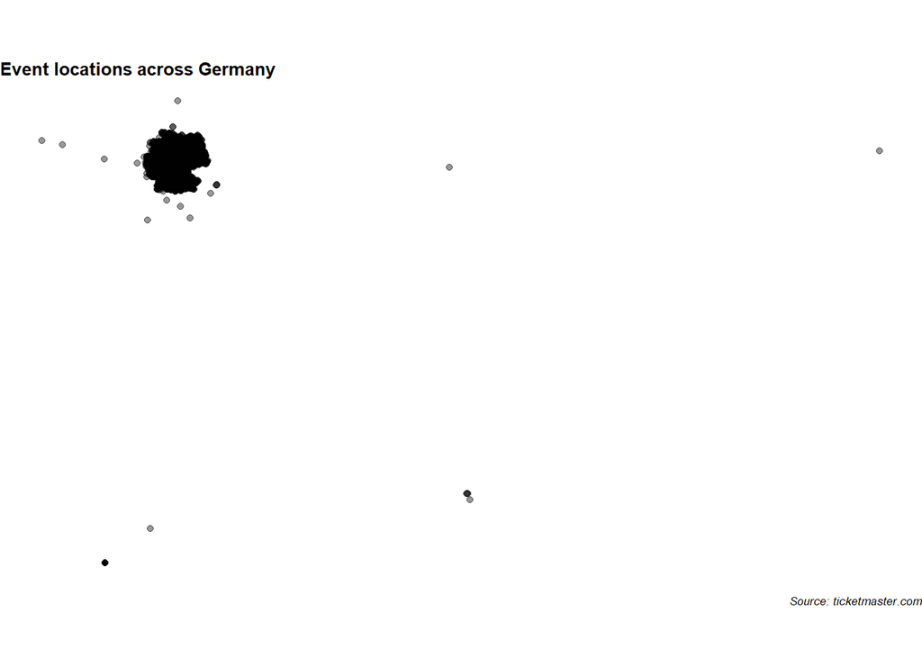

```r
# based on the code that is mentioned in the assignment
ggplot(german_df) +
borders("world", "Germany", colour = "black", fill = "grey90") +
  # add geom_point to create points for the locations
  # add alpha to make points transparent (-> to make overlaying points visible)
  geom_point(aes(longitude,latitude),
             alpha = 0.4) +
theme_void() +
coord_quickmap() +
labs(title = "Event locations across Germany",
caption = "Source: ticketmaster.com") +
theme(title = element_text(size = 8, face = 'bold'),
plot.caption = element_text(face = "italic"))
```

```r
# The visualization is not very practical, since Germany can not bee seen very
# well. In addition we have some points which are clearly located outside of
# Germany.
```

11. You will find that some coordinates lie way beyond the German borders and can be assumed to be faulty. Set coordinate values to NA where the value of longitude is outside the range (5.866, 15.042) or where the value of latitude is outside the range (47.270, 55.059) (these coordinate ranges have been derived from the extreme points of Germany as listed on Wikipedia (see here). For extreme points of other countries, see here).

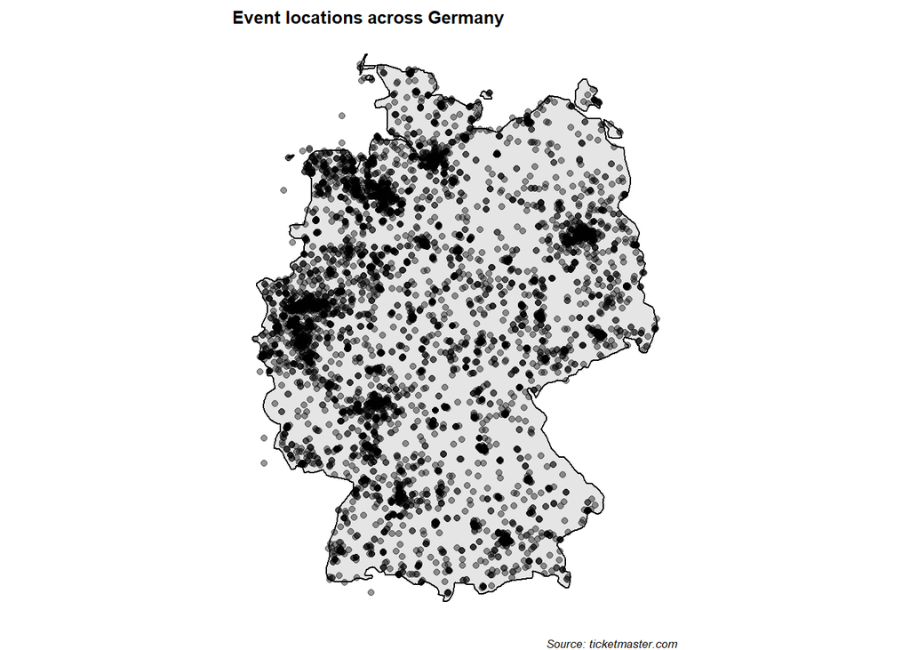

```r
# create NAs for latitude / longitude if  outside from Germany
# write a function to make life easier for the next tasks

adapt_long_lat <- function(df_country,long_lower,long_upper,lat_lower,lat_upper){
  df_country$longitude <- ifelse(df_country$longitude < long_lower, NA, df_country$longitude)

  df_country$longitude <- ifelse(df_country$longitude > long_upper, NA, df_country$longitude)

  df_country$latitude <- ifelse(df_country$latitude < lat_lower, NA, df_country$latitude)

  df_country$latitude <- ifelse(df_country$latitude > lat_upper, NA, df_country$latitude)

  return(df_country)
}

# Longitude is out of the range (5.866, 15.042) or where the value of latitude is
# outside the range (47.270, 55.059)
venue_de_adjust <- adapt_long_lat(german_df, 5.866, 15.042, 47.270, 55.059)

# visualize venues with new
# based on the code that is mentioned in the assignment
ggplot(venue_de_adjust) +
borders("world", "Germany", colour = "black", fill = "grey90") +
  # add geom_point to create points for the locations
  # add alpha to make points transparent (-> to make overlaying points visible)
  geom_point(aes(longitude,latitude),
             alpha = 0.4) +
theme_void() +
coord_quickmap() +
labs(title = "Event locations across Germany",
caption = "Source: ticketmaster.com") +
theme(title = element_text(size = 8, face = 'bold'),
plot.caption = element_text(face = "italic"))
```

```r
# The new data frame gives you a much better format where you can see all points
# very clear. Only some points are still located outside of Germany.
```

12. Repeat exercises (9)–(11) for another European country of your choice. (Hint: Clean code pays off! If you have coded the exercises efficiently, only very few adaptions need to be made.)

```r
# I will do the exercises 9 to 11 with the country Poland and its country
# code 'PL'

# Exercise 9
poland_df <- create_df("PL")
```

[output not shown]

[output cut: 44 more lines]

[output not shown]